# Progress and challenges in open-source multilevel modeling

14 May 2024

## Definitions and scope

## GLMMs: the biggest picture

- what is the scope of this talk?
- linear fixed effects (possibly with a link function)
- linear random effects/*latent variables* (ditto)
- known clusters with independent sets of latent variables
- multivariate Normal Gaussian distribution of latent variables

## in other words

\[ \begin{split} \underbrace{Y_i}_{\text{response}} & \sim \overbrace{\text{Distr}}^{\substack{\text{conditional} \\ \text{distribution}}}(\underbrace{g^{-1}(\eta_i)}_{\substack{\text{inverse} \\ \text{link} \\ \text{function}}},\underbrace{\phi}_{\substack{\text{scale} \\ \text{parameter}}}) \\ \underbrace{\boldsymbol \eta}_{\substack{\text{linear} \\ \text{predictor}}} & = \underbrace{\boldsymbol X\boldsymbol \beta}_{\substack{\text{fixed} \\ \text{effects}}} + \underbrace{\boldsymbol Z\boldsymbol b}_{\substack{\text{random} \\ \text{effects}}} \\ \underbrace{\boldsymbol b}_{\substack{\text{conditional} \\ \text{modes}}} & \sim \text{MVN}(\boldsymbol 0, \underbrace{\Sigma(\boldsymbol \theta)}_{\substack{\text{covariance} \\ \text{matrix}}}) \end{split} \]

… possibly allow **zero-inflation**/hurdle component, **dispersion** (scale) model (e.g. \(\phi = \exp(\boldsymbol X_d \beta_d (? + \boldsymbol Z_d \boldsymbol b_d ?))\))

## Past

## What is a “routine” model/analysis?

- computation time/cost
- availability of reliable software
- data size
- statistical complexity/sophistication
- ANOVA → linear models → GLMs → mixed models → ???

## Commoditization

- “goods … that are distinguishable in terms of attributes (uniqueness or brand) end up becoming simple commodities in the eyes of the market or consumers” ([Wikipedia](https://en.wikipedia.org/wiki/Commoditization))
- basic components become part of a **stack**/utilities for higher-level features
- operating system > linear algebra packages (BLAS, LAPACK) > regression tools > generalized linear models …
- build on top of old, well-tested frameworks

## Democratization

- as long as people are educated *enough*
- ¿can we afford enough statistical consultants?
- Efron: “recommending that scientists use [X] is like giving the neighborhood kids the key to your F-16” (Gelman 2008)  
  (*X = “Bayes’ Theorem” here but could be “mixed models”?*)
- want to make easy things easy and hard things possible

## Domain-specific languages

- DSLs can express a *limited* set of requirements
- R!
- *Wilkinson-Rogers-Bates* formulas (Wilkinson et al. 1973)
  - initial target: designed experiments
  - `GENOTYPE*POL(SITE, 1,SITEMEAN)*POLND(DENSITY)`
  - GENSTAT, expanded in S/R (Chambers et al. 1992)
  - expanded further to include random effects (Pinheiro et al. 2000)
  - further expansions … (`brms` package etc.)
- **too** compact (McElreath 2015)?  
  who really knows what `y ~ x1*x2 + (x1*x2|g)` means?

## Present

## Ever-expanding possibilities

- [Mixed models task view](https://cran.r-project.org/web/views/MixedModels.html): currently mentions 169 packages …

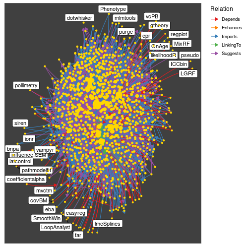

## Development and maintenance

Open source software is:

- powerful
- equitable
- reproducible
- transparent
- cutting-edge
- cheap!

## Development and maintenance

**BUT**:

- academics are paid to publish Cool Stuff
- researchers are paid to Get Stuff Done
- computational statisticians are rare
- mixed models are a niche market  
  (`lme4` is approximately 92d (out of 21K) on CRAN)

[figure not shown]

## Development models

[figure not shown]

## Future

## Machine learning/AI

[figure not shown]

from [sandserifcomics](https://www.instagram.com/sandserifcomics/)

## ML or ‘statistical’ learning

ML/SL:

- emphasis on algorithms and scalability
- prediction over inference (Breiman 2001)
- automatic differentiation

## autodiff everywhere

- magic algorithm
- CppAD, TMB, Stan, PyTorch, Tensorflow (`greta`), NIMBLE, …

## prediction ‘vs’ inference

- any ‘parameter’ of a model is an expectation of a change in the response
  - partial dependence (*marginal effects*), conditional dependence:
- users are almost always interested in *counterfactuals*
- … and estimates of uncertainty (or they should be)
- uncertainty in a counterfactual effect == inference ???
- connections to **causal inference**

## Smooths everywhere

- Revisit this layer: \(\boldsymbol b\sim \text{MVN}(\boldsymbol 0, \Sigma(\boldsymbol \theta))\)
- if \(\Sigma\) is diagonal then this is equivalent to putting a *ridge penalty* (\(\boldsymbol b\boldsymbol b^\top = \sum b_i^2\)) on the conditional modes
- we could use structured covariance matrices (compound symmetry, AR1, etc.)
- … penalizing by \(\boldsymbol b\Sigma \boldsymbol b^T\) is equivalent to using a **smoothing matrix** \(\Sigma^{-1}\)
- Gaussian processes, splines, Markov random fields …
- `mgcv` package provides implementations that can be used anywhere (Wood 2017)
  - including efficient low-rank approximations
  - `gamm4`, `glmmTMB`, `sdmTMB`, `brms` …

## Scalability

- dimensions of a mixed model
  - number of observations (\(10^2\) - \(10^8\))
  - number of latent variables (\(10\) - \(10^4\))
  - number of clusters (\(10\) - \(10^4\))
  - number of top-level parameters (\(\beta\), \(\theta\)): \(10\) - \(1000\)
- MLE scaling typically \({\cal O}(N^{3/2})\); method-of-moments \({\cal O}(N)\)  
  (stochastic gradient descent???)
- Recent work on scalable MM, (Hillary M. Heiling et al. 2024a; Hillary M. Heiling et al. 2024b; Gao et al. 2017; Gao et al. 2020; Ghosh et al. 2022a; Ghosh et al. 2022b; Ghandwani et al. 2023)

## Algorithms

## Sparsity

- computational trick or statement about the world?
- combining mixed models with sparsity-inducing penalization (e.g. `glmmLasso`)
- statement about an **effect size spectrum**
  - ridge penalty (\(\sum \beta_i^2\)) == Gaussian prior on effects
  - lasso penalty (\(\sum |\beta_i|\)) == Laplacian prior on effects
- or, what fits best??

## Sliding toward Bayes

- regularization/priors
  - Bayes: justified by *belief*
  - frequentism: justified by
    - decreased bias (e.g. Firth logistic regression)
    - decreased error ([Stein’s paradox](https://en.wikipedia.org/wiki/Stein%27s_example), ridge regression)
- empirical Bayes: regularization/priors only on intermediate layers
- maximum *a posteriori* (MAP) estimation: INLA, `blme`
- for good confidence intervals, MCMC is faster than parametric bootstrapping (e.g. pharmacokinetic models)

## Why aren’t we all Bayesian?

- concern about subjectivity, ease of use (Efron 1986)
- Bayes is still slower

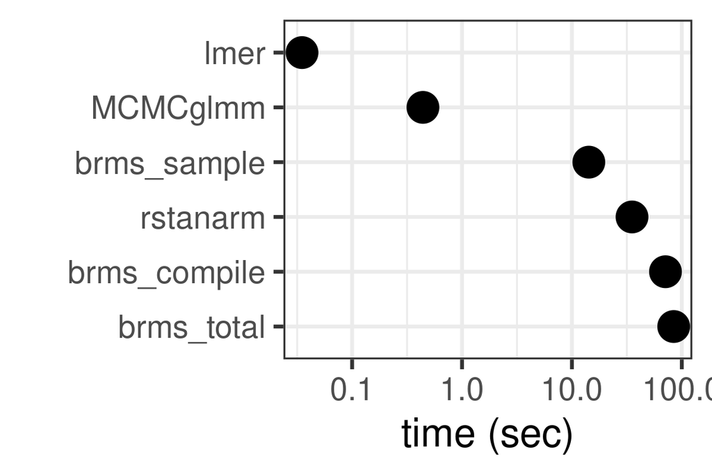

## references

Breiman, L. 2001. *Statistical Science* 16 (3) (August): 199–215. http://www.jstor.org/stable/2676681.

Chambers, JM et al. 1992. In *Statistical Models in S*. Routledge.

Efron, B. 1986. *The American Statistician* 40 (1) (February): 1–5. doi:10.1080/00031305.1986.10475342. https://www.tandfonline.com/doi/abs/10.1080/00031305.1986.10475342.

Gao, K et al. 2017. *Electronic Journal of Statistics* 11 (1): 1235–1296. doi:10.1214/17-EJS1236. https://projecteuclid.org/euclid.ejs/1492135234.

Gao, K et al. 2020. *Statistica Sinica* 30 (4): 1741–1771. https://www.jstor.org/stable/26969394.

Gelman, A. 2008. *Bayesian Analysis* 3: 445–450. doi:10.1214/08-BA318. http://ba.stat.cmu.edu/journal/2008/vol03/issue03/gelman.pdf.

Ghandwani, D et al. 2023. arXiv. doi:10.48550/arXiv.2307.12378. http://arxiv.org/abs/2307.12378.

Ghosh, S et al. 2022a. *Electronic Journal of Statistics* 16 (2) (January): 4604–4635. doi:10.1214/22-EJS2047. https://projecteuclid.org/journals/electronic-journal-of-statistics/volume-16/issue-2/Scalable-logistic-regression-with-crossed-random-effects/10.1214/22-EJS2047.full.

——— et al. 2022b. *The Annals of Statistics* 50 (1) (February): 560–583. doi:10.1214/21-AOS2121. https://projecteuclid.org/journals/annals-of-statistics/volume-50/issue-1/Backfitting-for-large-scale-crossed-random-effects-regressions/10.1214/21-AOS2121.full.

Heiling, Hillary M et al. 2024a. *Biometrics* 80 (1) (March): ujae016. doi:10.1093/biomtc/ujae016. https://doi.org/10.1093/biomtc/ujae016.

Heiling, Hillary M et al. 2024b. arXiv. doi:10.48550/arXiv.2305.08204. http://arxiv.org/abs/2305.08204.

McElreath, R. 2015. *Statistical Rethinking: A Bayesian Course with Examples in R and Stan*. Boca Raton: Chapman; Hall/CRC.

Pinheiro, JC et al. 2000. *Mixed-effects models in S and S-PLUS*. New York: Springer.

Wilkinson, GN et al. 1973. *Applied Statistics* 22 (3): 392–399. doi:10.2307/2346786.

Wood, S. 2017. *Generalized additive models: An introduction with r*. 2d ed. CRC texts in statistical science. Chapman & Hall.